# Exploration of real bulk RNA-seq datasets

ReCount data SRP047233

Yuqing Zhang

2018-10-19

### Introduction

ReCount is a public database of pre-processed RNA-seq gene count data. The SVAseq paper (Leek 2014) used 2 studies with gene measurements in two separate Hapmap populations, and looked for differentially expressed genes between genders in the two studies combined. Exploration of the same ReCount data used in SVAseq are summarized in a separate file (svaseq_recount).

Here, I searched the ReCount database with the keyword “batch”, and found a few datasets with abstracts containing this word (which means that the dataset potentially has batch effect). One of them is SRP047233 (Sugathan et al. 2014). This dataset aims to investigate the impact of decreased CHD8 expression on the expression of genes in downstream (CHD8-regulated) network. Truncating mutation of CHD8 is an important risk factor for autism spectrum disorder (ASD).

#### Overall design

RNA-seq in NPCs treated with shRNAs targeting CHD8. For controls, NPCs were treated with shRNAs targeting GFP and LacZ. Infection and sequencing was carried out in two separate batches, with one GFP and one LacZ sample in each batch. All samples were sequenced in two technical replicates. (https://trace.ncbi.nlm.nih.gov/Traces/sra/?study=SRP047233)

#### Download data & basic info

First, we download the data using the recount R package as shown in its vignette. Note that we use the read_counts() function instead of scale_counts() to convert the provided base pair counts to read counts, so that we get the raw counts without normalization.

After downloading the data, we calculate a few basic statistics of the dataset.

```
######  Samples  #######
- Total number of samples:
[1] 54

- Number of samples in condition groups:
group
CHD8  GFP LacZ
  34   10   10

- Number of samples in batches:
batch
 1  2
30 24
In batch 1:
CHD8  GFP LacZ
  18    6    6
In batch 2:
CHD8  GFP LacZ
  16    4    4


######  Genes  #######
- Total number of genes:
[1] 58037

- Number of genes with 0 counts:
[1] 37177.000     0.641

- Number of genes with ONLY 0s:
[1] 11976.000     0.206
```

For the following analysis, **we remove genes with all-zero values across all samples**.

```r
## Remove genes with all 0 counts
rse_gene <- rse_gene[apply(assay(rse_gene, "counts"), 1, function(x){!all(x==0)}), ]
print(dim(rse_gene))
```

```
[1] 46061    54
```

The figure below shows distribution of percentages of zero counts for the remaining genes (each data point represents a gene, i.e., how many zeros are there in each gene).

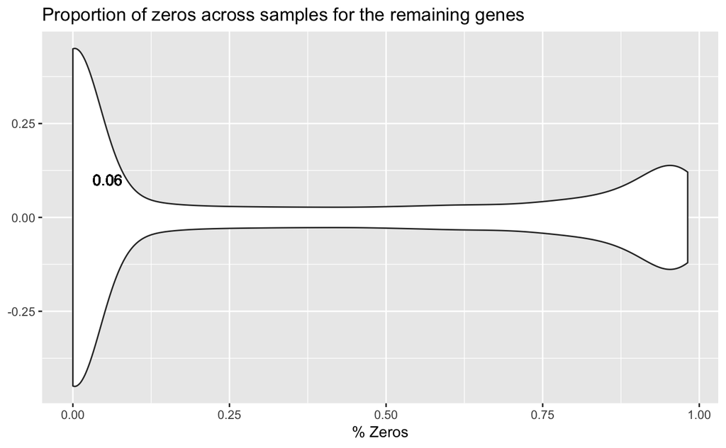

### Existence of batch effect

We first visualize the data using PCA and hierarchical clustering, to see if there is any batch effect in the dataset. Based on these plots, I believe there exists a certain level of batch effect in the data, as samples cluster more by batch than by biological condition.

#### PCA

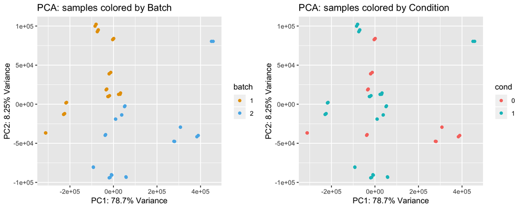

#### Dendrograms

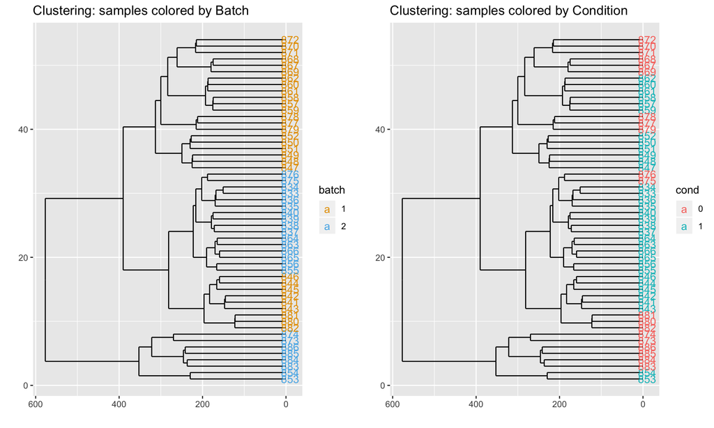

### Library size

Next, we take a look at the observed library sizes of samples, and to see if there is a difference in library size across batches.

```
Range of observed library sizes across samples:
[1] "4.14e+06" "3.15e+07"
```

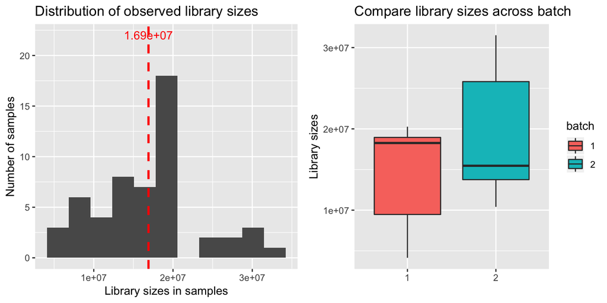

### Gene expression distribution

Our next step is to interrogate the gene expression distributions.

We first simply plot the counts, CPM, and log2CPM of 10 randomly chosen genes in the dataset. These figures are stored under directory specified by output_dir.

#### Fold changes in mean

We then use edgeR to perform differential expression analysis, and calculate (log-) fold changes of all genes between condition groups and batches.

##### Change WRT condition

To rule out the impact of batch effect, we limit our DE analysis WRT biological condition in one of the batches. Here we specify the batch to be **Batch 1**.

```r
####  Differential genes relative to biological condition
####  (within batch 1 / batch specified by 'test_batch')
test_batch <- 1
counts_batch <- assay(rse_gene,"counts")[, batch==test_batch]
cond_batch <- group_num[batch==test_batch]
y <- DGEList(counts=counts_batch, group=as.factor(cond_batch))
y <- calcNormFactors(y, method="TMM")
design <- model.matrix(~as.factor(cond_batch))
y <- estimateDisp(y, design)
fit <- glmQLFit(y, design)
qlf <- glmQLFTest(fit, coef=2)
de_res <- topTags(qlf, n=nrow(rse_gene))

up_genes <- rownames(de_res)[de_res$table$logFC >= 0]  # all up-regulated genes
head_up_genes <- head(up_genes, n=50)  # top-50 up-regulated genes
tail_up_genes <- tail(up_genes, n=50)  # 50 least up-regulated genes
down_genes <- rownames(de_res)[de_res$table$logFC < 0]  # all down-regulated genes
head_down_genes <- head(down_genes, n=50)  # top-50 down-regulated genes
tail_down_genes <- tail(down_genes, n=50)  # 50 least down-regulated genes
```

```
 ######  Changes in terms of mean gene counts  ######
         top50 up top50 down 100 least DE
Controls   233.32     713.39        97.18
Cases      516.87     365.62       104.20

 ######  Range of fold change across biological conditions  ######
       top50 up top50 down 100 least DE
min FC    1.811      0.009        0.925
max FC   75.489      0.623        1.000
```

##### Change WRT batch

We are also interested to see how the mean gene counts change across batches (i.e. **degree of mean batch effect**). To explore this mean batch effect, we perform DE WRT batch. To rule out the impact of biological condition, we perform this analysis within **control** samples only. Note that this DE is not true DE - it’s testing if there is a significant mean difference between two batches. Some genes will not be different in mean, while some will. Which means that batch doesn’t affect all genes in the same way.

```r
####  Differential genes relative to batch
####  (within condition 0 / condition specified by 'test_cond')
test_cond <- 0
counts_cond <- assay(rse_gene,"counts")[, group_num==test_cond]
batch_cond <- batch[group_num==test_cond]
y <- DGEList(counts=counts_cond, group=as.factor(batch_cond))
y <- calcNormFactors(y)
design <- model.matrix(~as.factor(batch_cond))
y <- estimateDisp(y, design)
fit <- glmQLFit(y, design)
qlf <- glmQLFTest(fit, coef=2)
de_res <- topTags(qlf, n=nrow(rse_gene))
up_genes <- rownames(de_res)[de_res$table$logFC >= 0]  # all up-regulated genes
head_up_genes <- head(up_genes, n=50)  # top-50 up-regulated genes
tail_up_genes <- tail(up_genes, n=50)  # 50 least up-regulated genes
down_genes <- rownames(de_res)[de_res$table$logFC < 0]  # all down-regulated genes
head_down_genes <- head(down_genes, n=50)  # top-50 down-regulated genes
tail_down_genes <- tail(down_genes, n=50)  # 50 least down-regulated genes
```

```
 ######  Batch differences in terms of mean gene counts  ######
       top50 up top50 down 100 least DE
Batch1   335.15     845.83        44.23
Batch2  1325.03     461.23        70.65

 ######  Range of fold change across biological conditions  ######
- All genes:
0 7.837
- Top genes:
       top50 up top50 down 100 least DE
min FC    1.935      0.001        0.956
max FC  461.897      0.525        1.000
```

#### Dispersion

Aside from mean gene counts, we are also interested in dispersions in the two batches. We plot the gene-wise dispersion estimates from edgeR:

[output not shown]

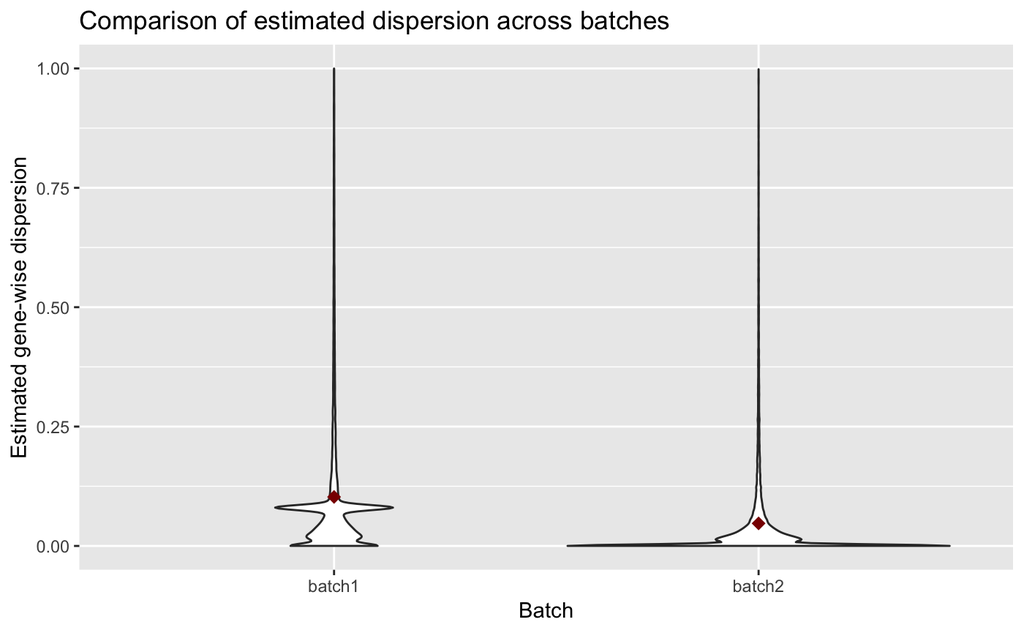

### Summary

- There exists a certain level of batch effect in this dataset.

### References

Leek, Jeffrey T. 2014. “Svaseq: Removing Batch Effects and Other Unwanted Noise from Sequencing Data.” *Nucleic Acids Research* 42 (21). Oxford University Press: e161–e161.

Sugathan, Aarathi, Marta Biagioli, Christelle Golzio, Serkan Erdin, Ian Blumenthal, Poornima Manavalan, Ashok Ragavendran, et al. 2014. “CHD8 Regulates Neurodevelopmental Pathways Associated with Autism Spectrum Disorder in Neural Progenitors.” *Proceedings of the National Academy of Sciences* 111 (42). National Acad Sciences: E4468–E4477.